Note

Go to the end to download the full example code or to run this example in your browser via JupyterLite or Binder.

# Plot the support vectors in LinearSVC

Unlike SVC (based on LIBSVM), LinearSVC (based on LIBLINEAR) does not provide the support vectors. This example demonstrates how to obtain the support vectors in LinearSVC.

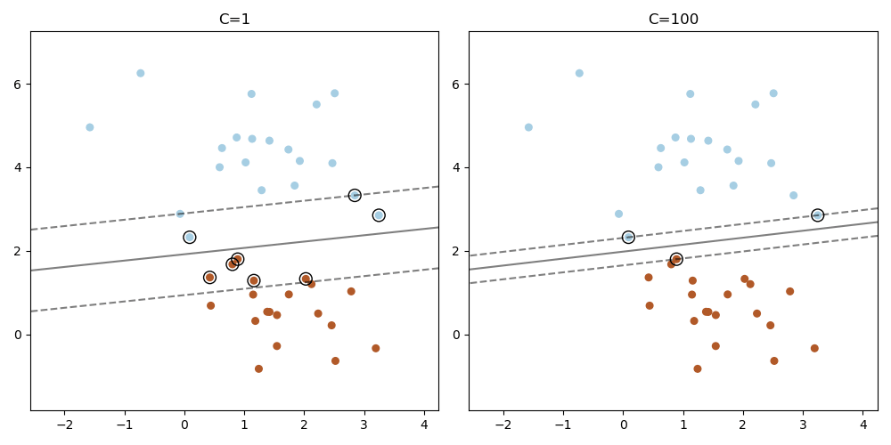

```
# Authors: The scikit-learn developers
# SPDX-License-Identifier: BSD-3-Clause

import matplotlib.pyplot as plt
import numpy as np

from sklearn.datasets import make_blobs
from sklearn.inspection import DecisionBoundaryDisplay
from sklearn.svm import LinearSVC

X, y = make_blobs(n_samples=40, centers=2, random_state=0)

plt.figure(figsize=(10, 5))
for i, C in enumerate([1, 100]):
    # "hinge" is the standard SVM loss
    clf = LinearSVC(C=C, loss="hinge", random_state=42).fit(X, y)
    # obtain the support vectors through the decision function
    decision_function = clf.decision_function(X)
    # we can also calculate the decision function manually
    # decision_function = np.dot(X, clf.coef_[0]) + clf.intercept_[0]
    # The support vectors are the samples that lie within the margin
    # boundaries, whose size is conventionally constrained to 1
    support_vector_indices = (np.abs(decision_function) <= 1 + 1e-15).nonzero()[0]
    support_vectors = X[support_vector_indices]

    plt.subplot(1, 2, i + 1)
    plt.scatter(X[:, 0], X[:, 1], c=y, s=30, cmap=plt.cm.Paired)
    ax = plt.gca()
    DecisionBoundaryDisplay.from_estimator(
        clf,
        X,
        ax=ax,
        grid_resolution=50,
        plot_method="contour",
        colors="k",
        levels=[-1, 0, 1],
        alpha=0.5,
        linestyles=["--", "-", "--"],
    )
    plt.scatter(
        support_vectors[:, 0],
        support_vectors[:, 1],
        s=100,
        linewidth=1,
        facecolors="none",
        edgecolors="k",
    )
    plt.title("C=" + str(C))
plt.tight_layout()
plt.show()
```

**Total running time of the script:** (0 minutes 0.208 seconds)

[figure not shown]

[`Download Jupyter notebook: plot_linearsvc_support_vectors.ipynb`](https://scikit-learn.org/1.9/_downloads/12a392e818ac5fa47dd91461855f3f77/plot_linearsvc_support_vectors.ipynb)

[`Download Python source code: plot_linearsvc_support_vectors.py`](https://scikit-learn.org/1.9/_downloads/036b9372e2e7802453cbb994da7a6786/plot_linearsvc_support_vectors.py)

[`Download zipped: plot_linearsvc_support_vectors.zip`](https://scikit-learn.org/1.9/_downloads/aba5d73e169336038beb51608b748211/plot_linearsvc_support_vectors.zip)

#### Related examples

Plot different SVM classifiers in the iris dataset

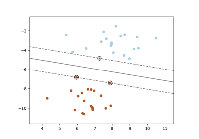

SVM: Maximum margin separating hyperplane

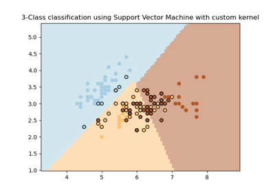

SVM with custom kernel

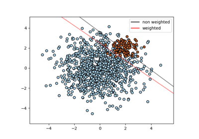

SVM: Separating hyperplane for unbalanced classes

© 2007–2026 The scikit-learn developers  
Licensed under the 3-clause BSD License.  
https://scikit-learn.org/1.9/auto_examples/svm/plot_linearsvc_support_vectors.html